# Homework 4

Kyle Landolt

March 7, 2015

```r
library(tidyr)
library(ggplot2)
library(dplyr)
library(magrittr)
setwd("~/Dropbox/GEOG415/klandolt/homework4")
```

1. Two-sample T-test> ACT scores Consider the hypothesis that college-bound males and females have the same average ACT scores.

```r
act <- read.table('ACT_scores.txt', header=TRUE)
act <- gather(act, key=sex, value=score)
```

1. Write out the hypothesis that is tested by a two-sample t-test in this case.

**Null Hypothesis: There will no difference in the mean of the male ACT scores and the mean of the female ACT score. In otherwords, the difference of the means will equal 0.**

Alternate Hypothesis: The will be a difference in the mean of the male ACT scores and the mean of the female ACT score. The difference of the means will not be equal to 0.

2. Using boxplots and summary statistics, report on the suitability of these data for a two-sample t-test to evaluate the hypothesis that sex influences score.

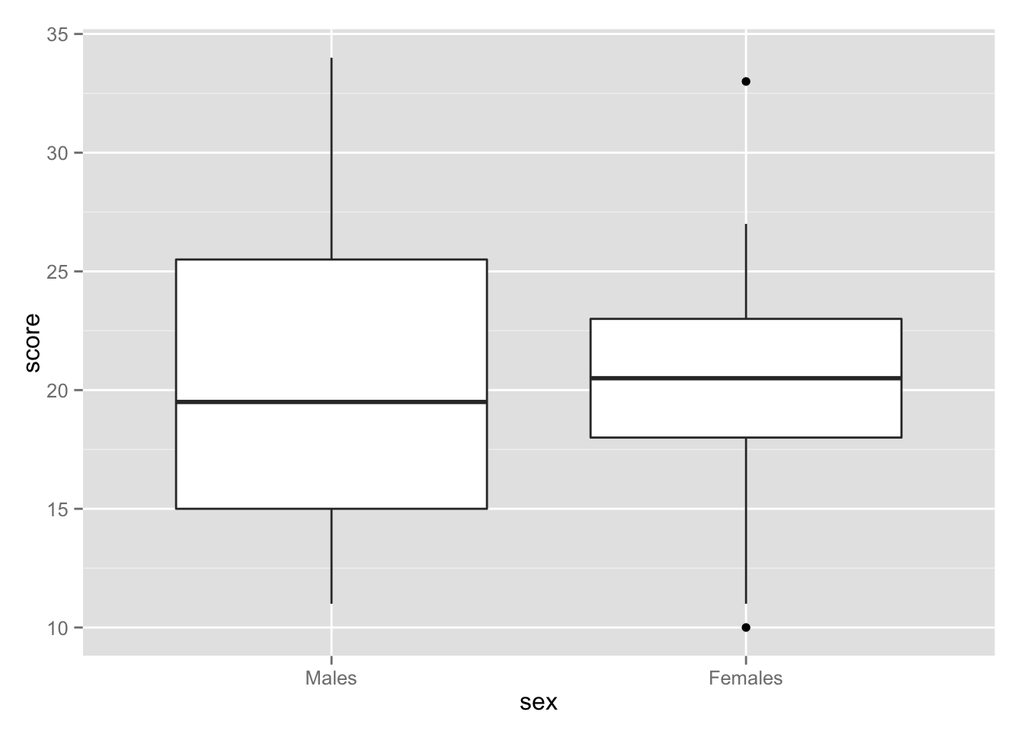

```r
ggplot(act) + geom_boxplot(aes(x=sex, y=score))
```

**The boxplots appear to show that the distribution of male scores and female scores are normal. Normally distributed data is required for proper two-sample t-testing.**

```r
summary(aov(score~sex, data=act))
```

```
##             Df Sum Sq Mean Sq F value Pr(>F)
## sex          1    1.3    1.29   0.025  0.875
## Residuals   26 1331.1   51.20
```

**The summary statistics for the ANOVA return a ‘F-statistic’ of 0.025 and a ‘p-value’ of 0.875. The F-statistic is notably low which may show that there is no signficicant variance between the two means.**

```r
act %>% group_by(sex) %>% summarize(m=mean(score), s=sd(score), n = n())
```

```
## Source: local data frame [2 x 4]
##
##       sex        m        s  n
## 1   Males 20.85714 7.998626 14
## 2 Females 20.42857 6.198192 14
```

**Furthermore, the manually produced mean, standard deviation, and n-value is produced. This shows that male and female test scores have similar means, both around 20, and similar standard deviations, both around 7.**

3. Conduct a t-test to evaluate the hypothesis that sex influences score and report the result.

```r
t.test(score~sex, data=act)
```

```
##
##  Welch Two Sample t-test
##
## data:  score by sex
## t = 0.1585, df = 24.475, p-value = 0.8754
## alternative hypothesis: true difference in means is not equal to 0
## 95 percent confidence interval:
##  -5.147383  6.004526
## sample estimates:
##   mean in group Males mean in group Females
##              20.85714              20.42857
```

**The t-test shows that sex does not determine the scores of the ACT test. The confidence interval contains 0. We can’t reject our null hypothesis which states that the difference is means is equal to 0. If there was significant difference, then the 95 percent CI wouldn’t contain 0.**

2. Two-sample t-tests. Cloud Seeding.

These data were collected in Southern Florida between 1968 and 1972 to test a hypothesis that seeding silver iodide into clouds can promote rainfall. They appear in a number of intriductory texts, including a favorite intermediate text of mine: Ramsay and Schafer’s The Statistical Sleuth. The data contain 52 weather events that were deemed suitable for seeding. On each day an airplane flew the clouds and a payload was released. It was randomly determined whether the payload would contain silver iodide or not, but the pilots were unaware of this, i.e. the pilots were blind to the treatment. Following the flight, radar was used to measure the precipitation falling from the cloud (in units of acre-feet).

```r
library(Sleuth3)
data(case0301)
```

1. Using boxplots and summary statistics, report on the suitability of these data for a two-sample t-test to evaluate the hypothesis that seeding influences rainfall.

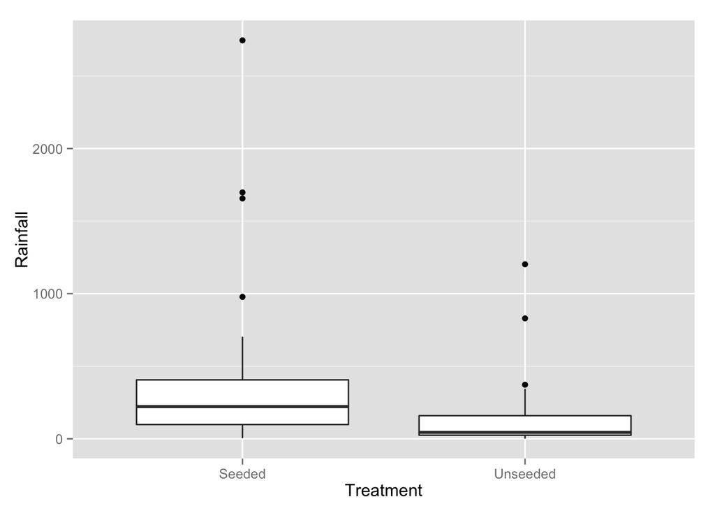

```r
ggplot(data=case0301) + geom_boxplot(aes(x=Treatment, y=Rainfall))
```

**The boxplots of Treatment to Rainfall show that there may be non-gaussian distributions of the data. There are skewed values for rainfall exceeding above 2000 which may prove to not be very reliable for two-sample t-tests.**

```r
summary(aov(Rainfall~Treatment, data=case0301))
```

```
##             Df   Sum Sq Mean Sq F value Pr(>F)
## Treatment    1  1000332 1000332   3.993 0.0511 .
## Residuals   50 12526130  250523
## ---
## Signif. codes:  0 '***' 0.001 '**' 0.01 '*' 0.05 '.' 0.1 ' ' 1
```

**The summary statistics for the ANOVA testing whether treatment has an affect on rainfall appear to be insignificant (F-value: 3.993, Pr(>F): 0.0511). This informs us that the ANOVA doesn’t show a signfinicant difference between rainfall events and treatments.**

```r
case0301 %>% group_by(Treatment) %>% summarize(m=mean(Rainfall), sd=sd(Rainfall), n=n() )
```

```
## Source: local data frame [2 x 4]
##
##   Treatment        m       sd  n
## 1    Seeded 441.9846 650.7872 26
## 2  Unseeded 164.5885 278.4264 26
```

**The means and standard deviations of the rainfall to treatments vary wildly. Seeded treatments have a extremely large standard deviation which may be a component of the non-gaussian distrubution.**

2. Conduct a t-test to evaluate the hypothesis that seeding influences rainfall and report the result.

```r
t.test(Rainfall~Treatment, data = case0301)
```

```
##
##  Welch Two Sample t-test
##
## data:  Rainfall by Treatment
## t = 1.9982, df = 33.855, p-value = 0.05377
## alternative hypothesis: true difference in means is not equal to 0
## 95 percent confidence interval:
##   -4.764295 559.556603
## sample estimates:
##   mean in group Seeded mean in group Unseeded
##               441.9846               164.5885
```

**The t-test to evaluate that seeding influences rainfall appears to be insignficant because the 95% CI contains 0 and the p-value is greater than 0.05. This means that two treatments, seeded and unseeded, have no significant differences.**

3. Repeat a. and b. using a log-transform of the rainfall measurement. Which analysis do you prefer and why?

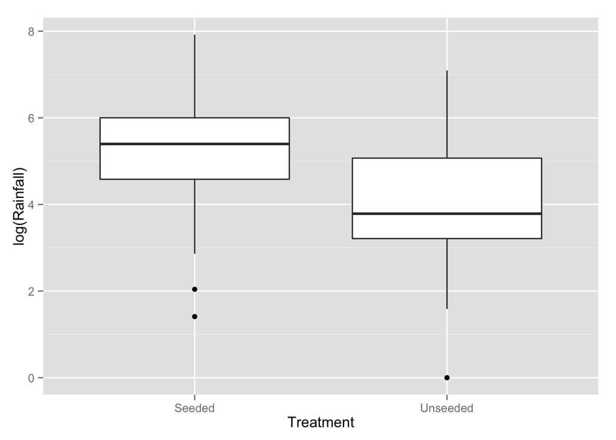

```r
ggplot(data=case0301) + geom_boxplot(aes(x=Treatment, y=log(Rainfall)))
```

**Here the boxplots of the Treatments to log(Rainfall) appear to distrubute the data much more normally than using non-logged Rainfall.**

```r
summary(aov(log(Rainfall)~Treatment, data=case0301))
```

```
##             Df Sum Sq Mean Sq F value Pr(>F)
## Treatment    1  17.01  17.007   6.474 0.0141 *
## Residuals   50 131.35   2.627
## ---
## Signif. codes:  0 '***' 0.001 '**' 0.01 '*' 0.05 '.' 0.1 ' ' 1
```

**The summary statistics of the ANOVA testing the variance of treatments to logged Rainfall appear to be significant. The F-value is larger than the previous test and the p-value is less than 0.05.**

```r
case0301 %>% group_by(Treatment) %>% summarize(m=mean(log(Rainfall)), sd=sd(log(Rainfall)), n=n() )
```

```
## Source: local data frame [2 x 4]
##
##   Treatment        m       sd  n
## 1    Seeded 5.134187 1.599514 26
## 2  Unseeded 3.990406 1.641847 26
```

**The mean and standard deviation of the log(Rainfall) to treatments appears to be more uniform and consistent as well.**

```r
t.test(log(Rainfall)~Treatment, data = case0301)
```

```
##
##  Welch Two Sample t-test
##
## data:  log(Rainfall) by Treatment
## t = 2.5444, df = 49.966, p-value = 0.01408
## alternative hypothesis: true difference in means is not equal to 0
## 95 percent confidence interval:
##  0.2408498 2.0467125
## sample estimates:
##   mean in group Seeded mean in group Unseeded
##               5.134187               3.990406
```

**The t test evaluating if the treatments have an affect on the log(Rainfall) appear to be signficiant in that we reject the null and accept the alternate hypothesis stating that there is a difference among means. The 95% CI doesn’t contain 0 which would mean that there wouldn’t be a significant difference in the means.**

**Ultimately, I prefer the log(Rainfall) to Treatment test because logging rainfall distributes the data much more normally that testing with the unlogged rainfall data. Normal distrubution are required for t testing evaluating the indedependent and dependent factor relationships.**

4. Why is it important that the pilots were unaware of whether they were seeding or not?

**It is important that the pilots were unaware of whether they were seeding or not so that there would be no bias in how they chose to fly the airplanes. If they did know, they might have taken difference flight patterns.**

5. Unfortunately, we do not have the date of the weather event. Why would it be helpful to have this information?

**The date of the weather event would be extremely useful because it would have helped us determine the weather on the day of the tests. If we knew the weather than we could have included that into our significance testing. For example, I assume that increased atmospheric humiditity would play a major roll in the success of seeding a cloud.**

2. ANOVA

Here are some simple data describing average daily temperatures for different cities grouped by season.

```r
# Create a dataset
temp = c(60,65,62,64,63,80,85,82,84,83,90,95,101,99,100)
season = rep( c('Fall', 'Spring', 'Summer'), times=c(5,5,5))

data <- data.frame(temp=temp, season=season)
```

For the air temperature data, conduct an ANOVA and use the F-statistic to test the hypothesis that air temperature varies by season.

```r
summary(aov(temp~season, data=data))
```

```
##             Df Sum Sq Mean Sq F value   Pr(>F)
## season       2 2952.1  1476.1   158.7 2.34e-09 ***
## Residuals   12  111.6     9.3
## ---
## Signif. codes:  0 '***' 0.001 '**' 0.01 '*' 0.05 '.' 0.1 ' ' 1
```

**Our F stastistic for testing whether temperature varied between seasons was 158.7. Our null hypothesis would be that the mean temperature for each season would be equal while the alternative would be that they would differ. Because our F-stastistic is exceedingly large, then we can state that the variance of the data between groups (seasons) is large and significantly different. The probabiblity of finding data that is crazier than this is 2.34e-09 which is much smaller than 0.05.**

3. Spock Conspiracy Trial.

This is another classic dataset. Dr. Benjamin Spock was a pediatrician who wrote a very popular book in 1948. In 1968, Dr Spock was accused of conspiring to violate the Selective Services Act by helping young men to medically avoid the military draft during the Vietnam War. His defence challeneged the case on the grounds that the jury did not contain a single woman, and therefore could not be random.

These data used here contain jury compositions for Spock’s judge and 6 other judges in the same court. For each jury, we have the fraction of the jury that was female.

```r
data(case0502)
```

1. Qualitatively describe these data using boxplots and summary statistics.

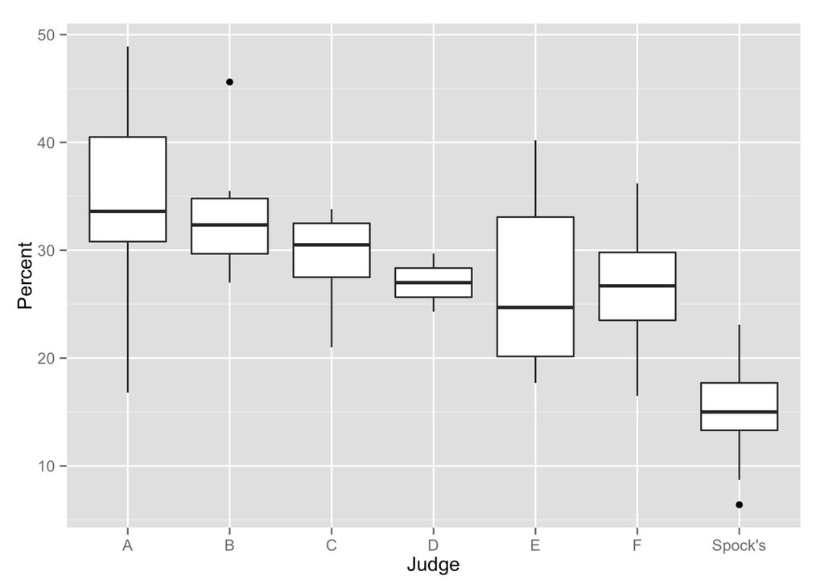

```r
ggplot(case0502) + geom_boxplot(aes(x=Judge, y = Percent))
```

```r
case0502 %>% group_by(Judge) %>% summarize(m=mean(Percent), sd=sd(Percent), n = n())
```

```
## Source: local data frame [7 x 4]
##
##     Judge        m        sd n
## 1       A 34.12000 11.941817 5
## 2       B 33.61667  6.582224 6
## 3       C 29.10000  4.592929 9
## 4       D 27.00000  3.818377 2
## 5       E 26.96667  9.010142 6
## 6       F 26.80000  5.968878 9
## 7 Spock's 14.62222  5.038794 9
```

2. Using an ANOVA, test the hypothesis that all of the judges have the same jury compositions on average and report your results.

```r
summary(aov(Percent~Judge, data=case0502))
```

```
##             Df Sum Sq Mean Sq F value  Pr(>F)
## Judge        6   1927   321.2   6.718 6.1e-05 ***
## Residuals   39   1864    47.8
## ---
## Signif. codes:  0 '***' 0.001 '**' 0.01 '*' 0.05 '.' 0.1 ' ' 1
```

**The ANOVA testing the hypothesis that the judges have the same jury composition have the same jury composition show that there is signficant difference among the judges. From the ANOVA, it can’t be said which Judge is significantly different though. We’ll have to group Judges A-F to test whether Spock differs from them.**

3. Grouping together Judges A-F, perform a two-sample t-test to test the hypothesis that Spock’s judge consistently chooses juries with lower than expected women.

```r
case0502$Judge2 <- ifelse(case0502$Judge == "Spock's", "Spock's", "Other")
t.test(Percent~Judge2, data=case0502)
```

```
##
##  Welch Two Sample t-test
##
## data:  Percent by Judge2
## t = 7.1597, df = 17.608, p-value = 1.303e-06
## alternative hypothesis: true difference in means is not equal to 0
## 95 percent confidence interval:
##  10.49935 19.23999
## sample estimates:
##   mean in group Other mean in group Spock's
##              29.49189              14.62222
```

**After grouping the judges together and running a two-sample t-test, we found significant difference between the percentages of women in the other Judges than in Spock’s. This is confirmed by the 95 percent CI not including 0.**

4. Use another ANOVA to evaluate whether or not it was suitable to group together the other 6 judges.

```r
summary(aov(Percent~Judge2, data=case0502))
```

```
##             Df Sum Sq Mean Sq F value   Pr(>F)
## Judge2       1   1601  1600.6   32.15 1.03e-06 ***
## Residuals   44   2191    49.8
## ---
## Signif. codes:  0 '***' 0.001 '**' 0.01 '*' 0.05 '.' 0.1 ' ' 1
```

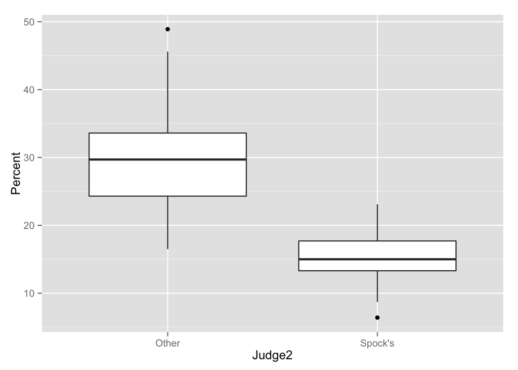

```r
ggplot(data=case0502) + geom_boxplot(aes(x=Judge2, y=Percent))
```

**The F-value found by testing the group of Judges to Spock was 32.15 with a p-value less than 0.05. This value shows that there is signficant difference between the two groups (Judges A-F and Spock). A boxplot visually shows the distribution of Spock’s to the group “Other”. I found that grouping the judges together was relevant to test Spock against all the other judges while maintaining normally distributed data.**

5. How should your interpretation of the results in part (c) change if you rejected the hypothesis the other six judges were not all statistically the same?

**If I rejected the hypothesis that the other six judges were not all statistically the same compared to Spock then I would have to state that Spock’s jury contained stastisticially just as much females than the other Judges.**